# Red Wine Analysis

## Multivariate Plots

As we saw, that alcohol plays a strong part in the quality of the wine even though it actually contributes only 22% of the total quality, now I will first make alcohol constant and try to insert a few more variables to see if they contribute to the overall quality in any other way.

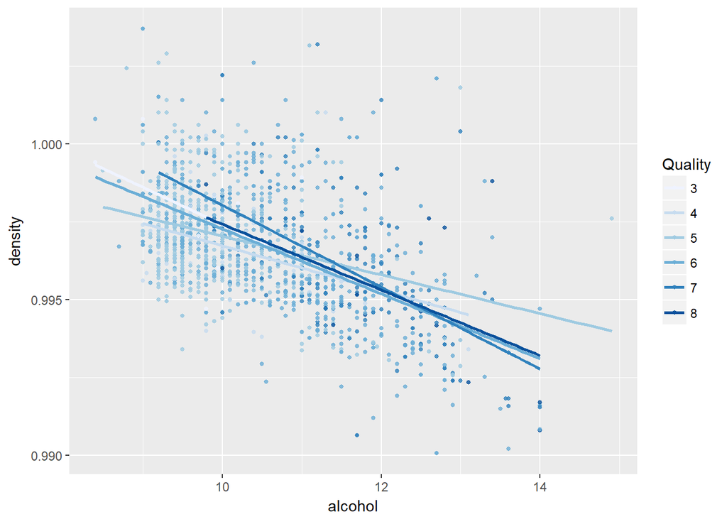

With constant Alcohol, Density does not seem to play a prominet role in changing the quality of the alcohol. So our previous suspicion must be true that the correlation we were seeing of density with quality was due to alcohol percent.

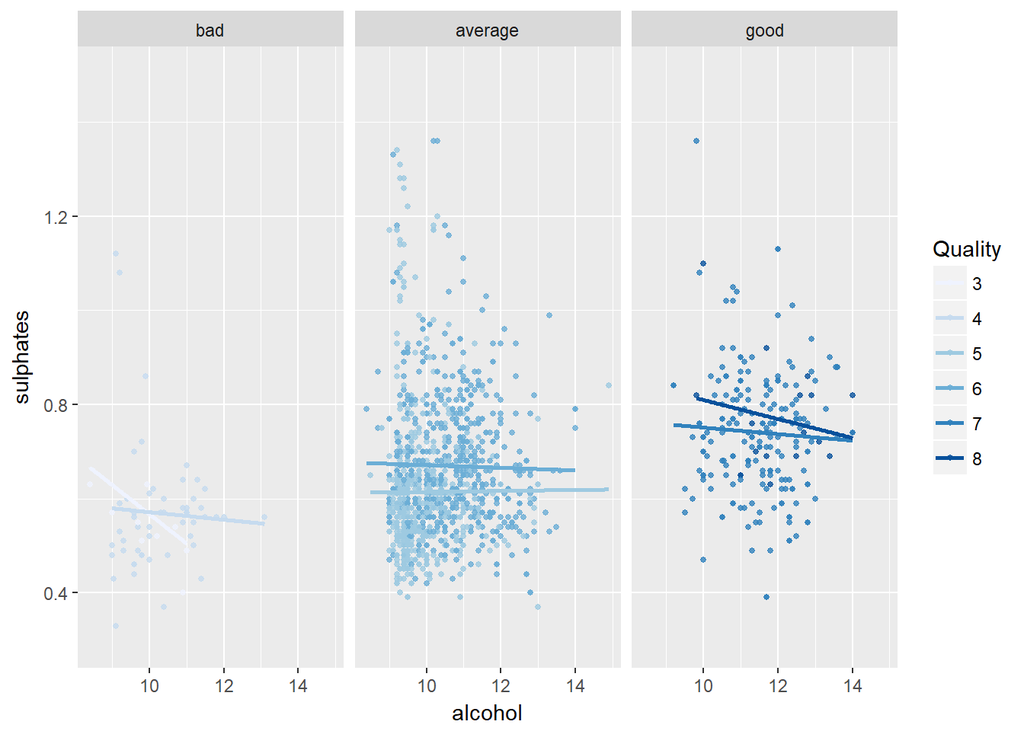

It looks like Wines with higher alcohol content produce better wine if they have higher level of Sulphates.

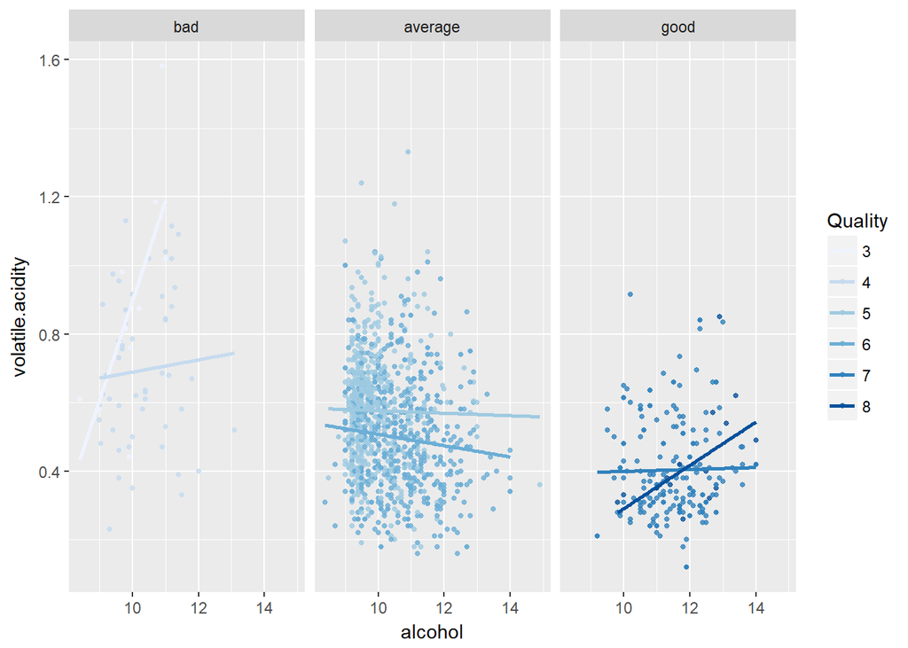

It looks like Volatile acid has just the opposite effect. With less concentration of volatile acid and higher concentration of alcohol seems to produce better wines.

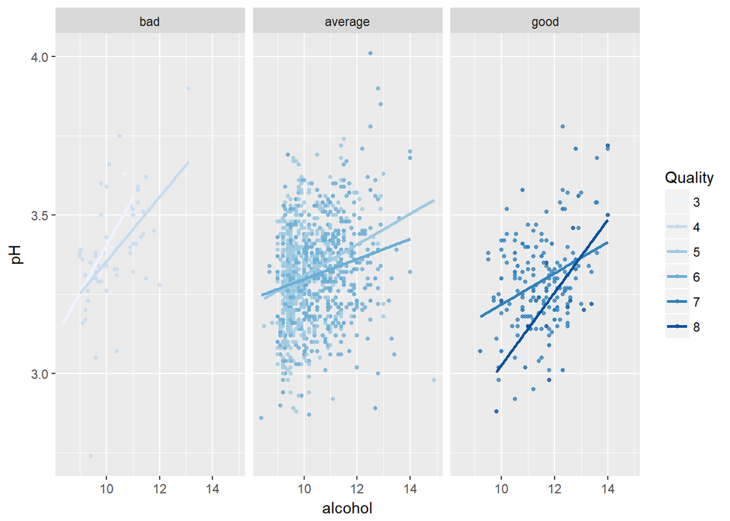

Here also, low pH and high Alcohol percentage seems to produce better wines.

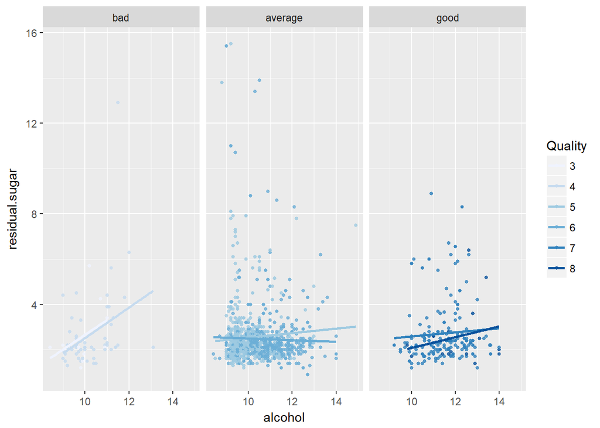

No such correlation between residual sugar and quality.

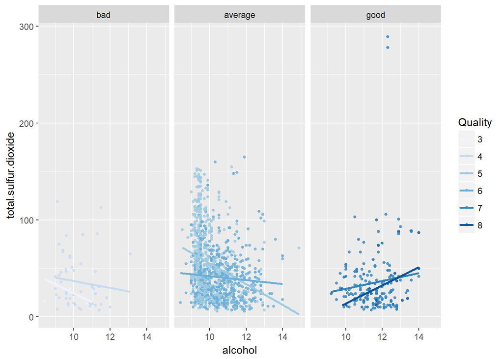

In general lower Sulphur Dioxide seems to produces better wine even though some high outliers for better wine with high Sulphur Dioxide.

Now let us try to investigate the effect of Acids on the Quality of Wines.

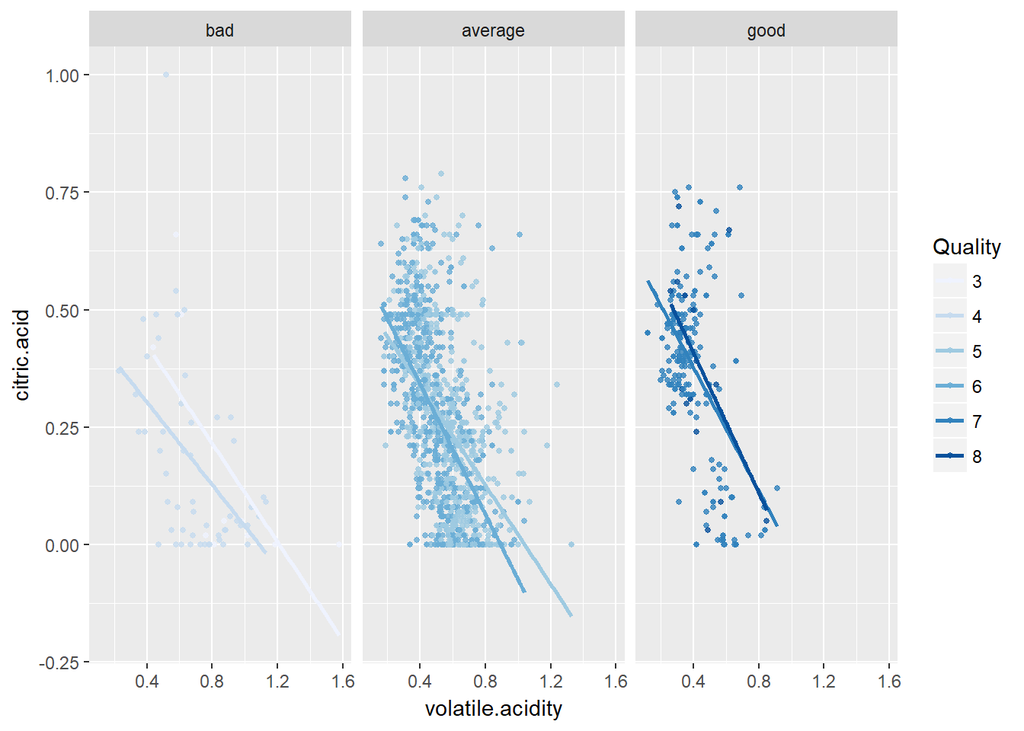

Higher Citric Acid and low Volatile Acid seems to produce better Wines.

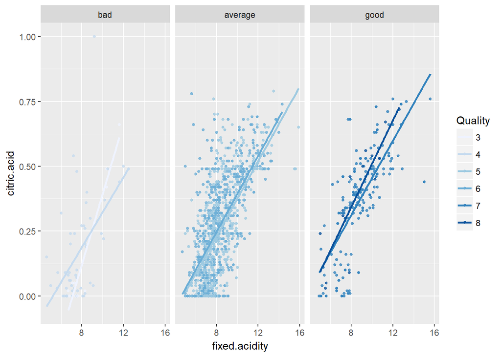

I don’t see much correlations here.

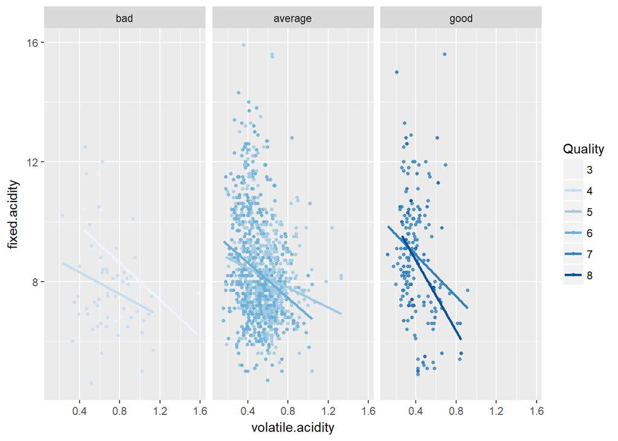

Again, I don’t get much correlation with the quality here.

## Linear Modelling

Now after all these analysis, I am going to take the variables which are most strongly correlated with the quality of the wine and generate a linear model with them.

````
```r
set.seed(1221)
training_data <- sample_frac(wine, .6)
test_data <- wine[ !wine$X %in% training_data$X, ]
m1 <- lm(as.numeric(quality) ~ alcohol, data = training_data)
m2 <- update(m1, ~ . + sulphates)
m3 <- update(m2, ~ . + volatile.acidity)
m4 <- update(m3, ~ . + citric.acid)
m5 <- update(m4, ~ . + fixed.acidity)
m6 <- update(m2, ~ . + pH)
mtable(m1,m2,m3,m4,m5,m6)
```

```
##
## Calls:
## m1: lm(formula = as.numeric(quality) ~ alcohol, data = training_data)
## m2: lm(formula = as.numeric(quality) ~ alcohol + sulphates, data = training_data)
## m3: lm(formula = as.numeric(quality) ~ alcohol + sulphates + volatile.acidity,
##     data = training_data)
## m4: lm(formula = as.numeric(quality) ~ alcohol + sulphates + volatile.acidity +
##     citric.acid, data = training_data)
## m5: lm(formula = as.numeric(quality) ~ alcohol + sulphates + volatile.acidity +
##     citric.acid + fixed.acidity, data = training_data)
## m6: lm(formula = as.numeric(quality) ~ alcohol + sulphates + pH,
##     data = training_data)
##
## ====================================================================================================
##                          m1            m2           m3           m4           m5           m6
## ----------------------------------------------------------------------------------------------------
##   (Intercept)           0.155        -0.273        0.866***     0.973***     0.497        1.494**
##                        (0.220)       (0.224)      (0.247)      (0.254)      (0.287)      (0.515)
##   alcohol               0.333***      0.320***     0.286***     0.284***     0.296***     0.339***
##                        (0.021)       (0.021)      (0.020)      (0.020)      (0.020)      (0.021)
##   sulphates                           0.855***     0.599***     0.650***     0.667***     0.733***
##                                      (0.126)      (0.124)      (0.127)      (0.126)      (0.129)
##   volatile.acidity                                -1.153***    -1.279***    -1.352***
##                                                   (0.124)      (0.143)      (0.144)
##   citric.acid                                                  -0.231       -0.629***
##                                                                (0.132)      (0.174)
##   fixed.acidity                                                              0.058***
##                                                                             (0.017)
##   pH                                                                                     -0.569***
##                                                                                          (0.149)
## ----------------------------------------------------------------------------------------------------
##   R-squared             0.209         0.245        0.308        0.310        0.319        0.256
##   adj. R-squared        0.208         0.243        0.306        0.307        0.315        0.254
##   sigma                 0.707         0.691        0.662        0.661        0.657        0.686
##   F                   252.335       155.125      141.769      107.317       89.264      109.700
##   p                     0.000         0.000        0.000        0.000        0.000        0.000
##   Log-likelihood    -1027.549     -1004.996     -963.139     -961.610     -955.575     -997.782
##   Deviance            478.652       456.660      418.487      417.154      411.937      449.841
##   AIC                2061.098      2017.992     1936.279     1935.219     1925.150     2005.565
##   BIC                2075.695      2037.456     1960.608     1964.415     1959.211     2029.894
##   N                   959           959          959          959          959          959
## ====================================================================================================
```
````

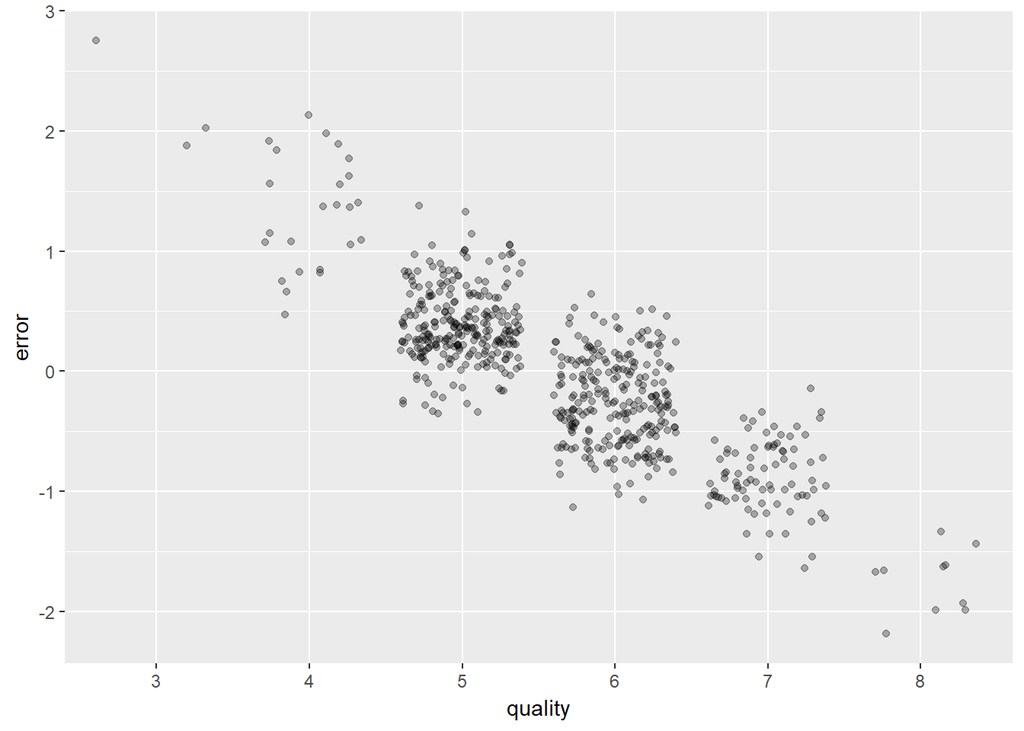

## Analysis of the Multivariate Plots

### Observations

1. High Alcohol and Sulaphate content seems to produce better wines.
2. Citric Acid, even though weakly correlated plays a part in improving the wine quality.

### Linear Models Created

I created a couple of linear models. But the main problem was there was not enough statistic to have a significant confidence level in the equations produced. Because of the low R squared value, I saw that alcohol contributes to only 22% of the Wine Quality and the most of the factors converged on the Average quality wines. This can be due to the fact that our dataset comprised mainly of ‘Average’ quality wines and as there were very few data about the ‘Good’ and the ‘Bad’ quality wines in the training dataset, that’s why it was difficult to predict statistics for the edge cases. Maybe a more complete dataset would have helped me better in predicting the higher range values.

## Final Plots and Summary

I saw that the Alcohol and Sulphates played a major role in determining alcohol quality. Also in the final linear model I made, I also plotted the error value against the quality which shows us the variation in the error percentage with different qualities of Wine. I think these three plots are very crtical plots for this project. So I decided to include these three plots in the Final Plots and Summary section.

### Plot 1

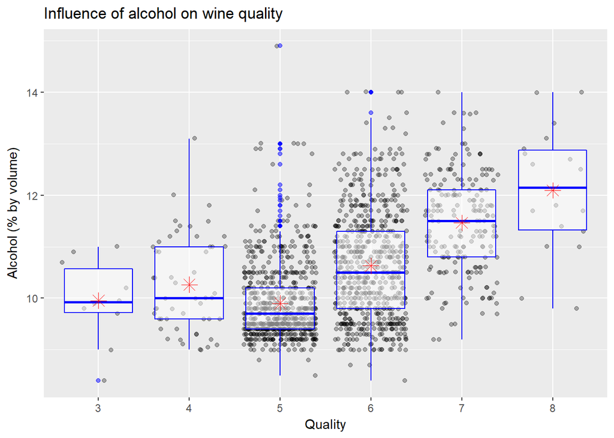

This plot tells us that Alcohol percentage has played a big role in determining the quality of Wines. The higher the alcohol percentage, the better the wine quality. In this dataset, even though most of the data pertains to average quality wine, we can see from the above plot that the mean and median coincides for all the boxes implying that for a particular Quality it is very normally distributed. So a very high value of the median in the best quality wines imply that almost all points have a high percentage of alcohol. But previously from our linear model test, we saw from the R Squared value that alcohol alone contributes to about 22% in the variance of the wine quality. So alcohol is not the only factor which is responsible for the improvement in Wine Quality.

### Plot 2

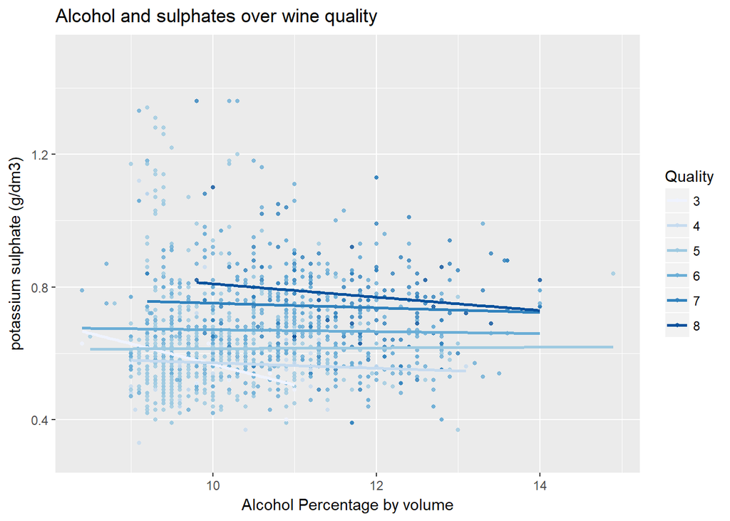

In this plot, we see that the best quality wines have high values for both Alcohol percentage and Sulphate concentration implying that High alcohol contents and high sulphate concentrations together seem to produce better wines. Although there is a very slight downwards slope maybe because in best quality wines, percentage of alcohol is slightly greater than the concentration of Sulphates.

### Plot 3

[output not shown]

We see that the error is much more dense in the ‘Average’ quality section than the ‘Good’ and the ‘Bad’ quality wines. This is evident from the fact that most of our dataset contains ‘Average’ quality wines and there is not too many data in the extreme ranges. The linear model with the R squared value for m5 could only explain around 33% change in quality. Also the earlier models clearly shows that due to the lack of information, it is not the best model to predict both ‘Good’ and ‘Bad’ quality wines.

## Reflections

In this data, my main struggle was to get a higher confidence level when predicting factors that are responsible for the production of different quality of wines especially the ‘Good’ and the ‘Bad’ ones. As the data was very centralized towards the ‘Average’ quality, my training set did not have enough data on the extreme edges to accurately build a model which can predict the quality of a wine given the other variables with lesser margin of error. So maybe in future, I can get a dataset about Red Wines with more complete information so that I can build my models more effectively.

Initially when I was writing and developing for this project, I saw that some wines didn’t have citric acid at all. Also the others showed almost a rectangular distribution. My first thought was maybe this was bad data or incomplete data. But then I researched further about wines. I saw that citric acid actually is added to some wines to increase the acidity. So it’s evident that some wines would not have Citric Acid at all. So actually this was in parallel to my experimental findings.

The other variables showed either a Positively skewed or a Normal Distribution.

First I plotted different variables against the quality to see Univariate relationships between them and then one by one I threw in one or more external factors to see if they together have any effect on the categorical variable. saw that the factors which affected the quality of the wine the most were Alcohol percentage, Sulphate and Acid concentrations.

I tried to figure out the effect of each individual acid on the overall pH of the wine. Here I found out a very peculiar phenomenon where I saw that for volatile acids, the pH was increasing with acidity which was against everything I learned in my Science classes.

But then to my utter surprise, for the first time in my life as a data analyst, I saw the legendary Simpson’s Paradox at play where one lurking variable was reversing the sign of the correlation and in turn totally changing the trend in the opposite direction.

In the final part of my analysis, I plotted multivariate plots to see if there were some interesting combinations of variables which together affected the overall quality of the wine. It was in this section I found out that density did not play a part in improving wine quality.

For future analysis, I would love to have a dataset, where apart from the wine quality, a rank is given for that particular wine by 5 different wine tasters as we know when we include the human element, our opinion changes on so many different factors. So by including the human element in my analysis, I would be able to put in that perspective and see a lot of unseen factors which might result in a better or worse wine quality. Having these factors included inside the dataset would result in a different insight altogether in my analysis.